# Model 1

# 1 Model 1

## 1.1 Treatments

- Cell 0 (SoC)
  - Counseling
  - 6 month HAZ effect: 0
- Cell 1
  - Counseling
  - Food: 7.5% PER, 10% ASP
  - Iron + Vitamin A + Zinc
  - 6 month HAZ effect: 0.0633
- Cell 2
  - Counseling
  - Food: 15% PER, 30% ASP
  - Multiple micronutrient supplementation
  - 6 month HAZ effect: 0.1037
- Cell 3
  - Counseling
  - Food: 15% PER, 30% ASP
  - Multiple micronutrient supplementation
  - Antibiotics + Probiotics
  - 6 month HAZ effect: 0.1574
- Cell 4
  - Counseling
  - Food: 15% PER, 30% ASP
  - Multiple micronutrient supplementation
  - Antibiotics + Probiotics
  - WASH Intensified
  - Psychosocial care and support
  - 6 month HAZ effect: 0.1687

## 1.2 Study design settings

These study design options were used for the current set of simulations:

- 3 recruitment cycles: 0, 6, and 12 months (study time).
- 2 recruitment age groups: 6 and 12 months (age).
- Instantaneous recruitment (all children recruited on day 1).
- The initial randomization set to 1:1:1:1:1.
- The minimum randomization probability for SoC is 20%.
- Treatment arms with a probability less than 10% *before* adjusting for the minimum SoC randomization probability is dropped.
- All available data up and including the timepoint for the interim analyses is used to update the probabilities.
- The dropout rate is approximately 20%/6 months.
- Bi-monthly HAZ observations.
- Interim analyses every 6 months.
- Square root probability updates (small probabilities are inflated)

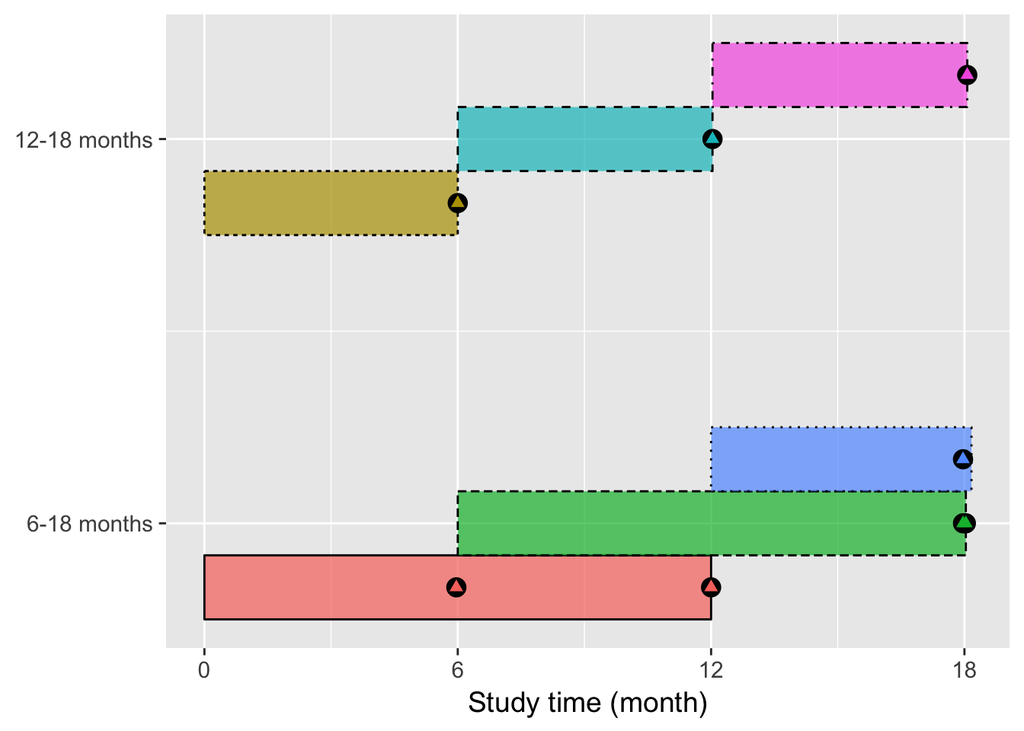

## 1.3 Results

The simulated HAZ data.

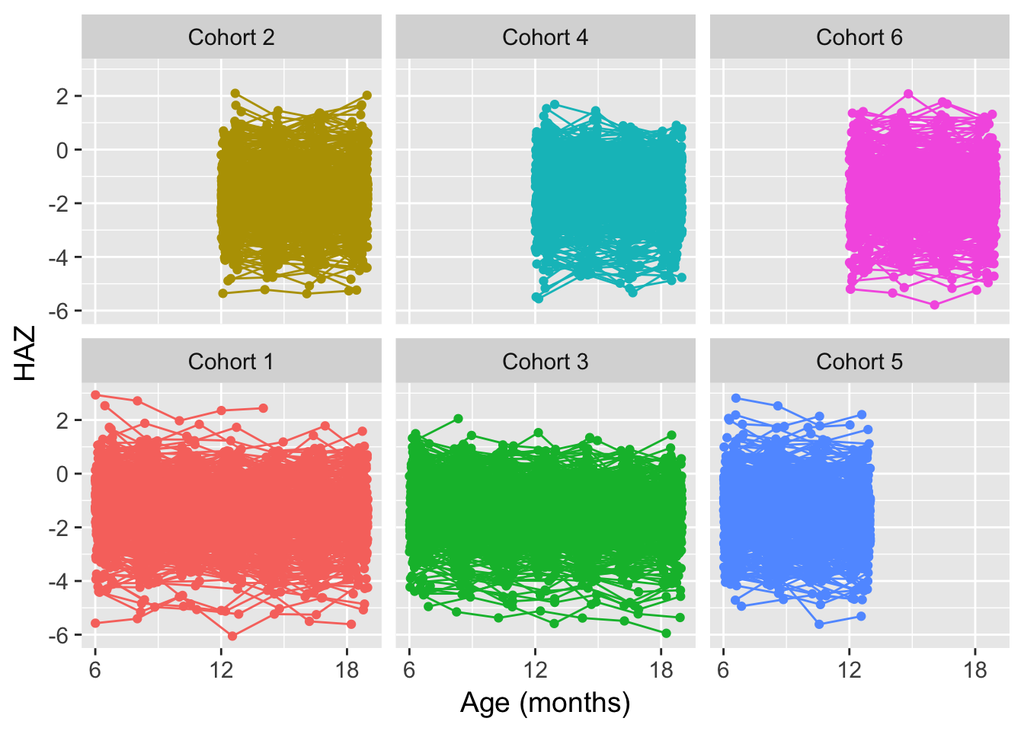

The randomization probabilties **before*** adjusting for the minimum SoC randomization probability.

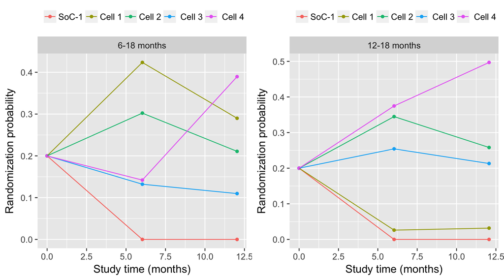

The randomization probabilties **after** adjusting for the minimum SoC randomization probability.

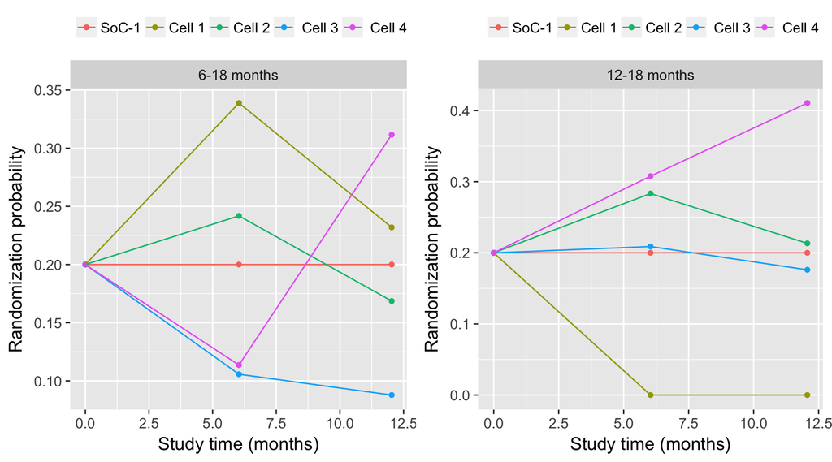

The final analysis of all the data gives the following probabilities:

| Treatment | Prob 6-18 months | Prob 12-18 months |
| --- | --- | --- |
| SoC-1 | 0.00 | 0.00 |
| Cell 1 | 0.08 | 0.00 |
| Cell 2 | 0.29 | 0.19 |
| Cell 3 | 0.07 | 0.21 |
| Cell 4 | 0.56 | 0.59 |

The final analysis of all the data gives the following estimated treatment effects (change in HAZ/6 months):

| Treatment | Eff 6-18 months | Eff 12-18 months |
| --- | --- | --- |
| Cell 1 | 0.07 | 0.00 |
| Cell 2 | 0.09 | 0.08 |
| Cell 3 | 0.06 | 0.08 |
| Cell 4 | 0.11 | 0.10 |

## 1.4 Repeating the study multiple times

Running the study multiple time (in this case **25 times**) allows for the computation of performance statistics.

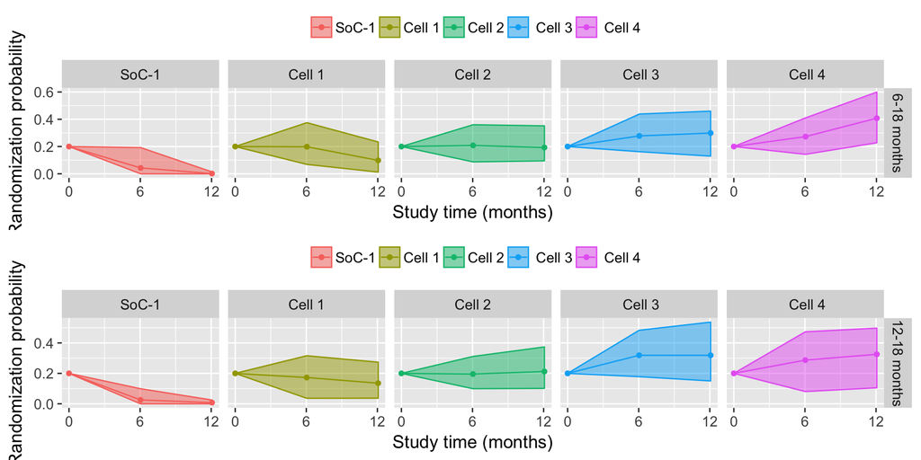

The randomization probabilties after adjusting for the minimum SoC randomization probability. The shaded areas are the 95% prediction intervals.

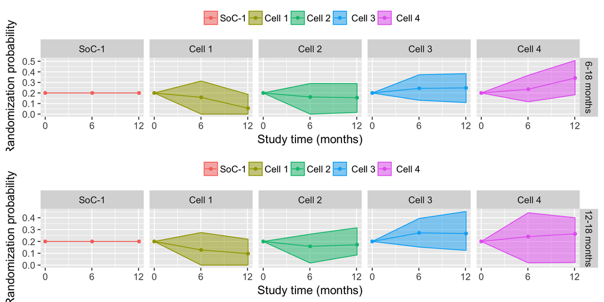

### 1.4.1 Performance metrics

To compare design choices quantitatively it is useful with performance metrics. Two suggestions are the randomization probabilities based on an analysis of all data (i.e. at the end of the trial) and the estimated treatment effects based on all data.

The “power” for Cell4 to be the best treatment in the two age groups are:

| Treatment | AgeGroup | Power |
| --- | --- | --- |
| Cell4 | 12-18 months | 0.56 |
| Cell4 | 6-18 months | 0.60 |

The randomization probabilities (the bars are 95% prrdiction intervals):

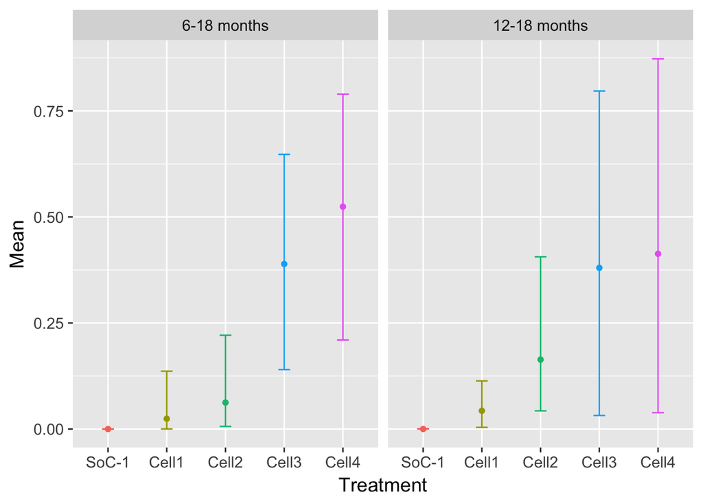

The treatment effects/6 months (the black dots are the true effects an the bars are 95% CI).

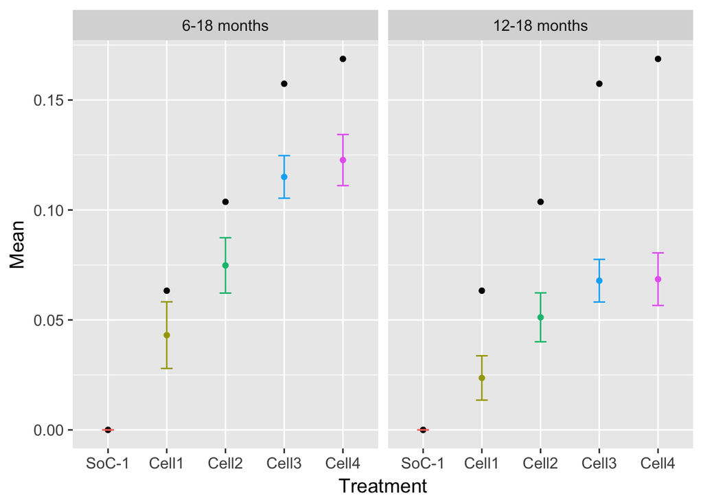